# 確率分布

2017-04-14

# 離散型

## 二項分布

ベルヌーイ試行をn回行って成功する回数Xが従う確率分布を二項分布と言う。Xが二項分布に従うとき$X～B(n,p)$と書く

n回のベルヌーイ試行を行うときｋ回成功する確率は下記の通り
$$P(X=k)=_{n}C_{k}p^k(1-p)^{n-k} (k=0,1,2,…,n)$$
期待値は$E[X]=np$
分散は$Var(X)=np(1-p)$

# 連続型

## 正規分布

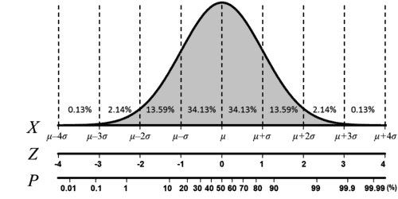

### ガウシアンフィッティング

[参考] http://d.hatena.ne.jp/n_shuyo/20091018/gaussian

## t分布

母平均の信頼区間の推定方法に使用される 標本数が少ない（30以下）場合に使用する

- 例 自由度9(=10-1)のt分布において有意水準5%で両側検定を行う

```r
qt(0.025,9)
```

```
[1] -2.262157
```

```r
qt(0.975,9)
```

```
[1] 2.262157
```

```r
x <- rnorm(10)
t.test(x)
```

```
    One Sample t-test

data:  x
t = -0.87574, df = 9, p-value = 0.4039
alternative hypothesis: true mean is not equal to 0
95 percent confidence interval:
 -1.1167214  0.4934024
sample estimates:
 mean of x
-0.3116595
```

- グラフ

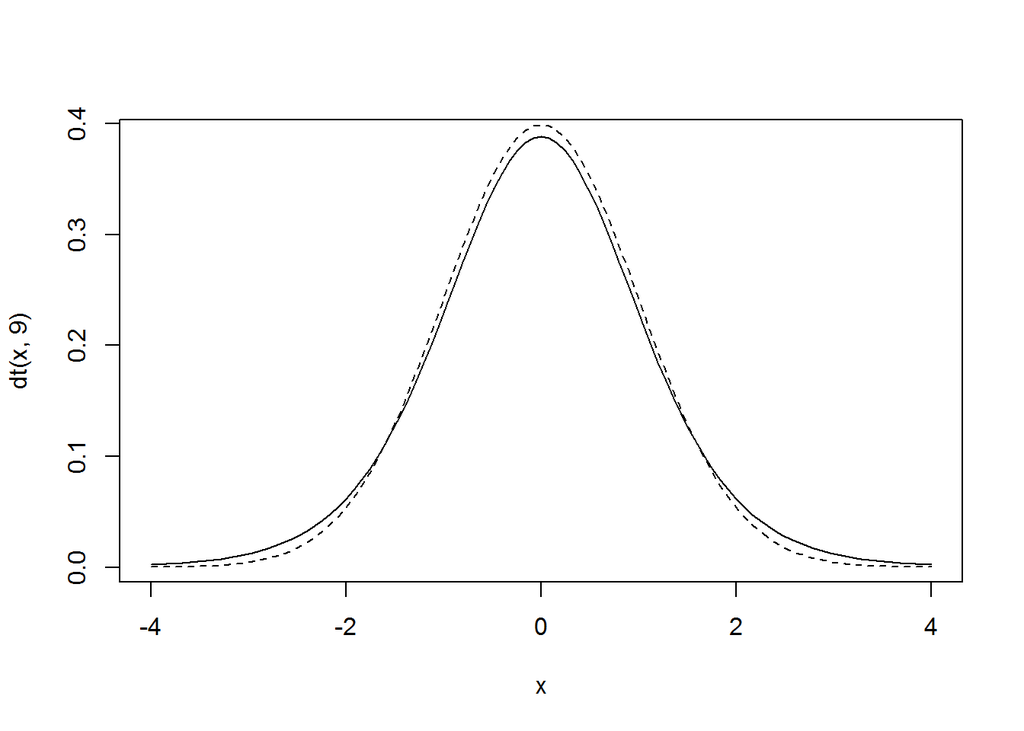

```r
x <- seq(-4, 4, 0.01)
curve(dt(x, 9),-4,4,type="l")
curve(dnorm(x),-4,4,type="l",lty=2,add=T)
```

## カイ2乗分布

自由度nのカイ2乗値は以下のように定義される

$$χ^2_{(n)} \equiv \displaystyle\sum_{i=1}^{n} z^2_{i} \equiv\ \frac{ \displaystyle\sum_{i=1}^{n}(x_{i}-μ)^2}{σ^2}$$

標本分散から母分散を推定するために使われる。母分散は不偏分散から以下の様に推定される

$$\frac{(n-1)\hat{\sigma}^2}{χ^2_(n-1,α/2)}
\leq
σ^2
\leq
\frac{(n-1)\hat{\sigma}^2}{χ^2_(n-1,1-α/2)}$$
αは有意水準

Rでは↓だけ

上側2.5%

```r
qchisq(0.975,4)
```

```
[1] 11.14329
```

下側2.5%

```r
qchisq(0.025,4)
```

```
[1] 0.4844186
```

- グラフ

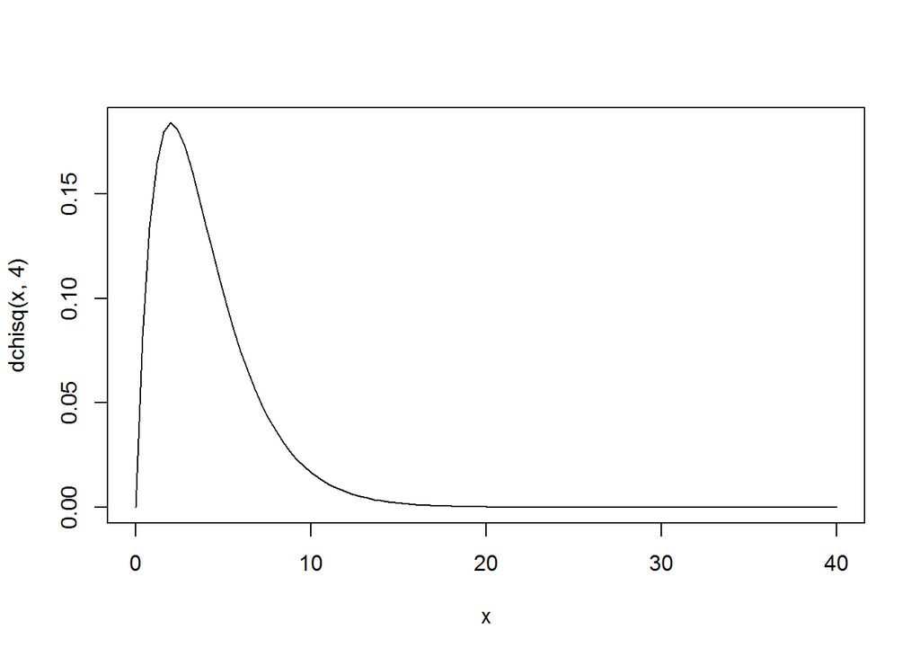

```r
x <- seq(-4, 4, 0.01)
curve(dchisq(x, 4),0,40,type="l")
```

## F分布

そもそもF値とは「標準席分布に従う2つの母集団から無作為抽出してきた2つのカイ2乗値の比である。

[参考] http://bio-info.biz/statistics/distribution_f_distribution.html

[参考] http://www.biwako.shiga-u.ac.jp/sensei/mnaka/ut/statdist.html